# Relatório Parcial OE1 2011-2019

#### 3.1.2 Brasil e concorrentes

- Dez concorrentes do Brasil foram selecionados para uma análise comparativa: Peru, República Dominicana, Colômbia, Espanha, Chile, Costa Rica, Jamaica, Cuba, Argentina e Mexico.

Figura 6: Mapa ilustrativo do Brasil e concorrentes selecionados

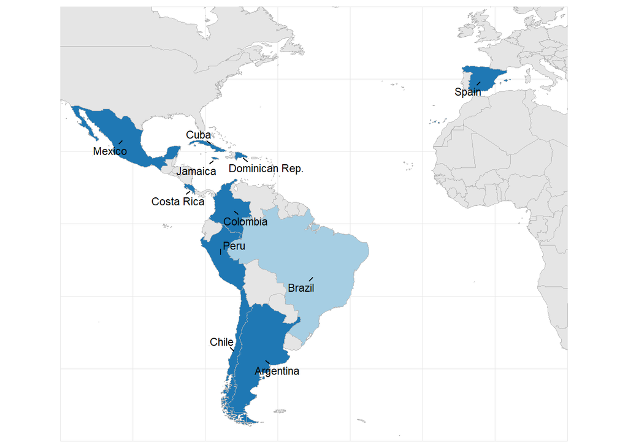

- A Espanha e, em segundo lugar, o México claramente destoam dos demais países deste grupo em termos de volume de chegadas internacionais.

Figura 7: Chegadas turísticas internacionais em países concorrentes selecionados - 2019 (milhão)

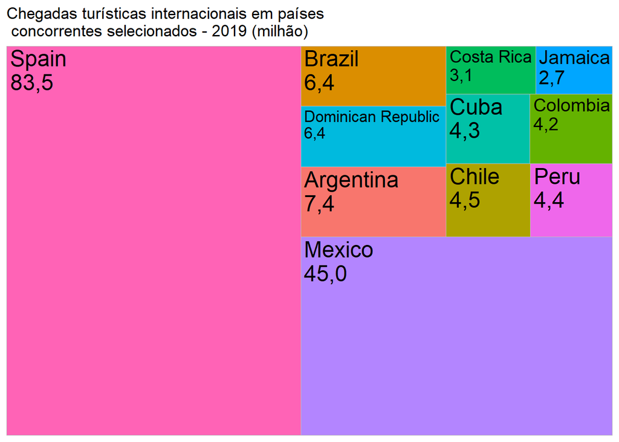

Figura 8: Distribuição das chegadas turísticas internacionais, por país

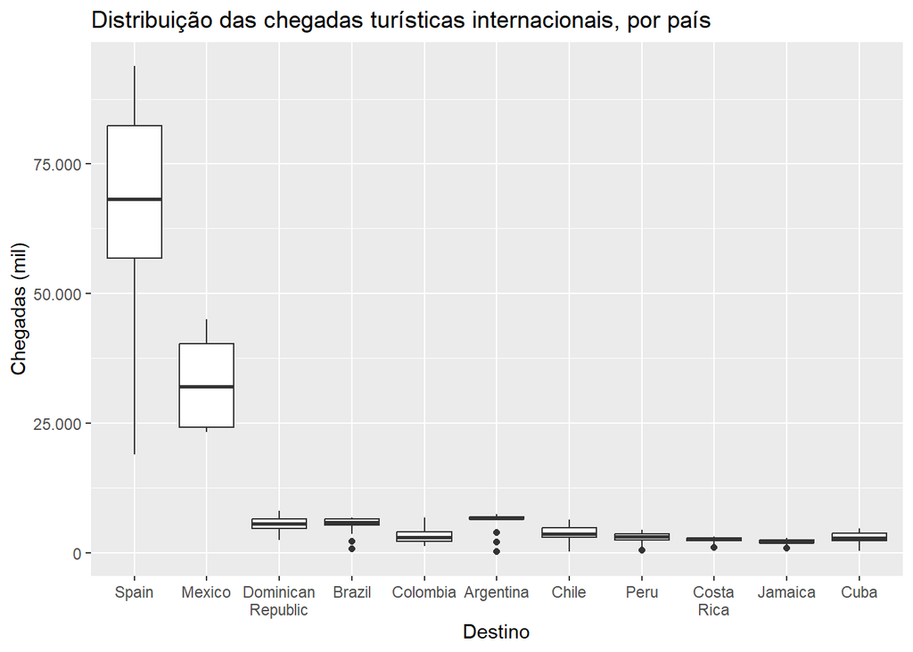

- O gráfico a seguir mostra o ranking destes países ao longo do tempo. Nota-se o Brasil majoritariamente na quarta posição, abaixo da Argentina e acima da República Dominicana.

Figura 9: Ranking anual de destinos por chegadas

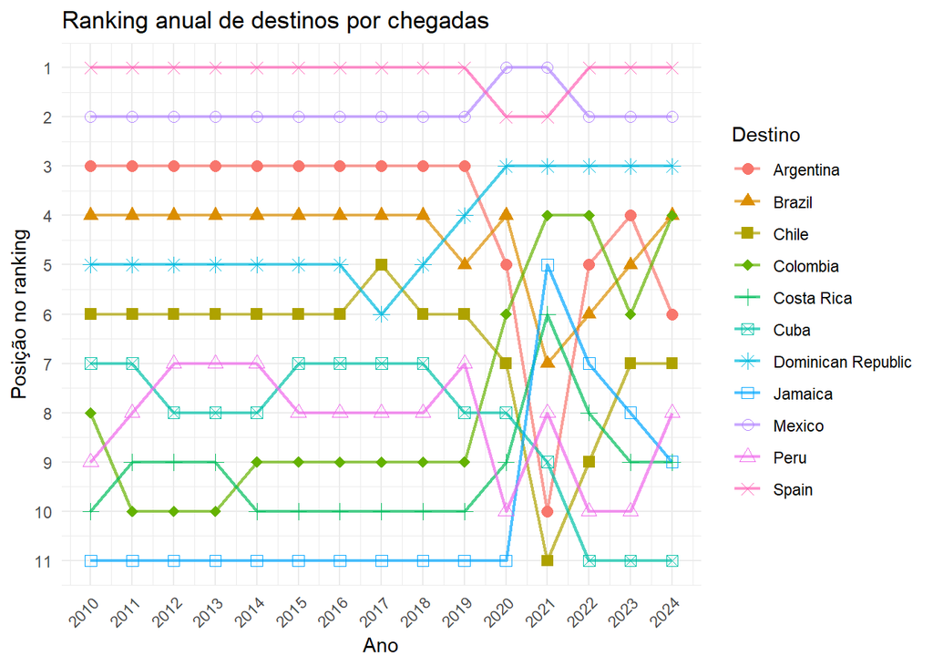

- Em 2024 o Brasil recebeu 6,8 milhões de visitantes, o mesmo número estimado pela ONU Turismo para a Colômbia e muito próximo do valor para a Argentina (6,6 milhões).
- Para o Brasil, 6,8 milhões representa o recorde da série histórica.
- O Brasil tem a quinta maior média de chegadas entre os 11 países analisados.